# **EE5178: Panoramic Stitching**

# Brief Overview

In this problem set, you will implement panoramic stitching. Given two input images, we will "stitch" them together to create a simple panorama. To construct the image panorama, we will use concepts learned in class such as keypoint detection, local invariant descriptors, RANSAC, and perspective warping.

The panoramic stitching algorithm consists of four main steps which we ask you to implement in individual functions:

1. Detect keypoints and extract local invariant descriptors from two input images.
2. Match the descriptors between the two images.
3. Apply RANSAC to estimate a homography matrix between the extracted features.
4. Apply a perspective transformation using the homography matrix to merge image into a panorama.

Functions to implement (refer to function comments for more detail):

1. get_features
2. match_keypoints
3. find_homography and transform_ransac
4. panoramic_stitching

# Starting

Run the following code to import the modules you'll need. After your finish the assignment, remember to run all cells and save the note book to your local machine as a .ipynb file for Canvas submission.

```python
%matplotlib inline
import cv2
import random
import numpy as np
import matplotlib.pyplot as plt
from google.colab.patches import cv2_imshow
import scipy.linalg
```

```python
%%capture
! wget -O img1.jpg "https://drive.google.com/uc?export=download&id=1omMydL6ADxq_vW5gl_1EFhdzT9kaMhUt"
! wget -O img2.jpg "https://drive.google.com/uc?export=download&id=12lxB1ArAlwGn97XgBgt-SFyjE7udMGvf"
```

# Visualize Input Images

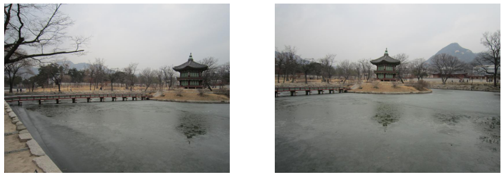

```python
img1 = plt.imread('img1.jpg')
img2 = plt.imread('img2.jpg')

def plot_imgs(img1, img2):
  fig, ax = plt.subplots(1, 2, figsize=(15, 20))
  for a in ax:
    a.set_axis_off()
  ax[0].imshow(img1)
  ax[1].imshow(img2)

plot_imgs(img1, img2)
```

```python
sift = cv2.xfeatures2d.SIFT_create()
```

# Compute SURF/ SIFT/ ORB Features and Match Keypoints

```python
def get_features(img):
  '''
    Compute SURF/SIFT/ORB features using cv2 library functions. Use default parameters when computing the keypoints.
    Input:
      img: cv2 image
    Returns:
      keypoints: a list of cv2 keypoints
      descriptors: a list of feature descriptors
  '''
  # ===============================================
  # TODO
  gray = cv2.cvtColor(img , cv2.COLOR_BGR2GRAY)
  keypoints, descriptors = sift.detectAndCompute(gray ,None)

  # ===============================================
  return keypoints, descriptors

def match_keypoints(desc_1, desc_2, ratio=0.75):
  '''
    You may use cv2 library functions.
    Input:
      desc_1, desc_2: list of feature descriptors
    Return:
      matches: list of feature matches
  '''
  # ===============================================
  # TODO
  bf = cv2.DescriptorMatcher_create("BruteForce")
  matches = bf.knnMatch(desc_1,desc_2 , k = 2)
  # matches = sorted(matches, key = lambda x:x.distance)
  good = []
  for m in matches:
    if len(m) == 2 and m[0].distance < m[1].distance * ratio:
      good.append(m[0])
  # good = good[::-1]
  matches = good
  # ===============================================
  return matches
```

```
keypoints for img1 and img2
```

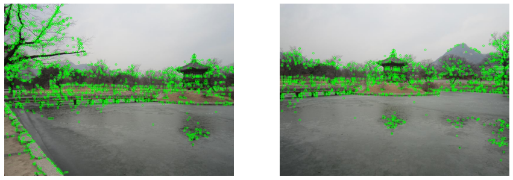

```python
kp_1, desc_1 = get_features(img1)
kp_2, desc_2 = get_features(img2)

kp_img1 = cv2.drawKeypoints(img1, kp_1, None, color=(0,255,0), flags=0)
kp_img2 = cv2.drawKeypoints(img2, kp_2, None, color=(0,255,0), flags=0)

print('keypoints for img1 and img2')
plot_imgs(kp_img1, kp_img2)
```

```
feature matches
```

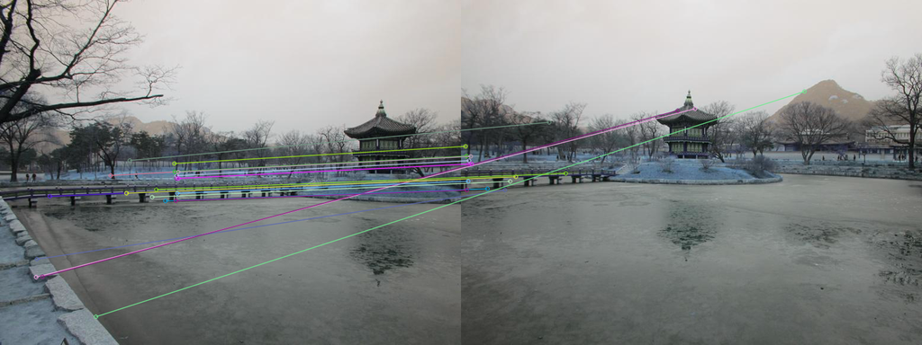

```python
matches = match_keypoints(desc_1, desc_2)
match_plot = cv2.drawMatches(img1, kp_1, img2, kp_2, matches[:20], None, flags=2)
print("feature matches")
cv2_imshow(match_plot)
```

Getting the (x,y) and (x',y')

```python
def getPointCorrespondences(matches , kp_1 , kp_2):
  X = []
  X_ = []
  for match in matches:
    X.append(kp_1[match.queryIdx].pt)
    X_.append(kp_2[match.trainIdx].pt)
  pts_1 = np.float32([[i[0] , i[1] , 1] for i in X])
  pts_2 = np.float32([[i[0] , i[1] , 1] for i in X_])
  return pts_1, pts_2
```